# Exploratory Data Analysis

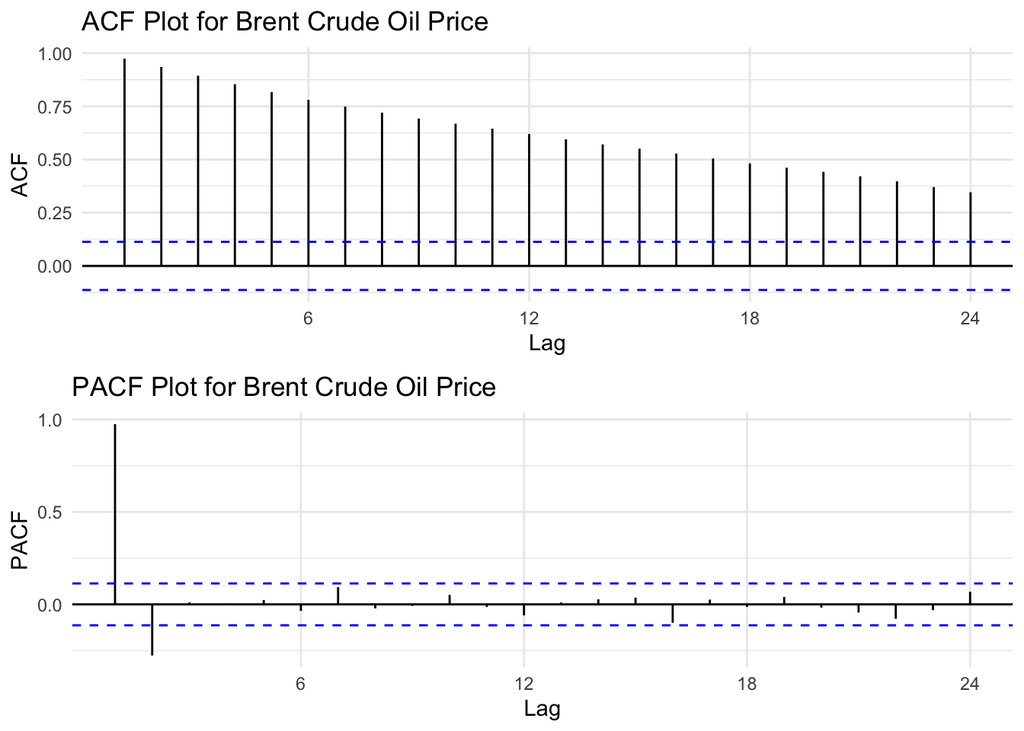

```r
acf4 <- ggAcf(brent_ts) +
  ggtitle("ACF Plot for Brent Crude Oil Price") +
  theme_minimal()

pacf4 <- ggPacf(brent_ts) +
  ggtitle("PACF Plot for Brent Crude Oil Price") +
  theme_minimal()

grid.arrange(acf4, pacf4, nrow = 2)
```

The ACF plot for Brent Crude Oil Price shows a slow and persistent decay, with strong positive correlations across multiple lags. This pattern indicates that oil prices exhibit strong temporal dependence and a long-term trend component. The PACF plot presents a single dominant spike at lag 1, after which correlations quickly approach zero. This behavior suggests that the Brent Crude Oil Price series is non-stationary, likely driven by underlying trends or gradual adjustments in global energy markets.

**U.S. Dollar Index**

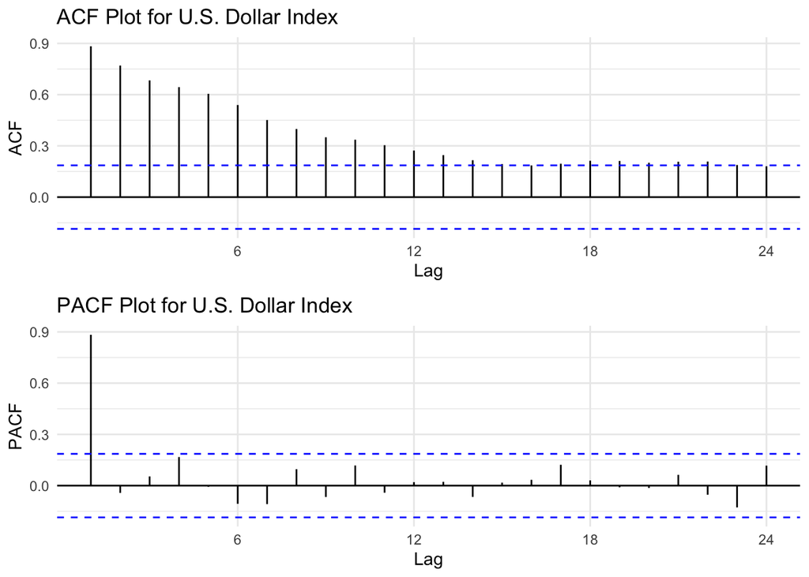

```r
acf5 <- ggAcf(usd_ts) +
  ggtitle("ACF Plot for U.S. Dollar Index") +
  theme_minimal()

pacf5 <- ggPacf(usd_ts) +
  ggtitle("PACF Plot for U.S. Dollar Index") +
  theme_minimal()

grid.arrange(acf5, pacf5, nrow = 2)
```

The ACF plot for the U.S. Dollar Index displays a gradually decaying pattern, with autocorrelations that remain positive for several lags before slowly diminishing. The PACF plot shows a significant spike at lag 1, followed by near-zero correlations afterward. This combination indicates that the Dollar Index is likely non-stationary, with potential trend persistence or inertia effects typical of macroeconomic indices.

**Global Supply Chain Pressure Index**

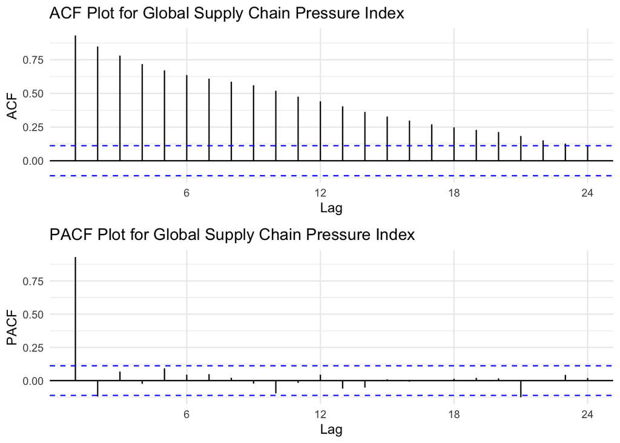

```r
acf6 <- ggAcf(gscpi_ts) +
  ggtitle("ACF Plot for Global Supply Chain Pressure Index") +
  theme_minimal()

pacf6 <- ggPacf(gscpi_ts) +
  ggtitle("PACF Plot for Global Supply Chain Pressure Index") +
  theme_minimal()

grid.arrange(acf6, pacf6, nrow = 2)
```

The ACF plot for the Global Supply Chain Pressure Index demonstrates high autocorrelation at short lags that slowly declines across longer lags, implying a strong persistence in global supply chain dynamics. The PACF plot shows a dominant spike at lag 1 with the remaining lags insignificant, suggesting that the series is non-stationary and heavily influenced by global macroeconomic shocks that evolve gradually over time.

**AHS Weighted Average Tariff**

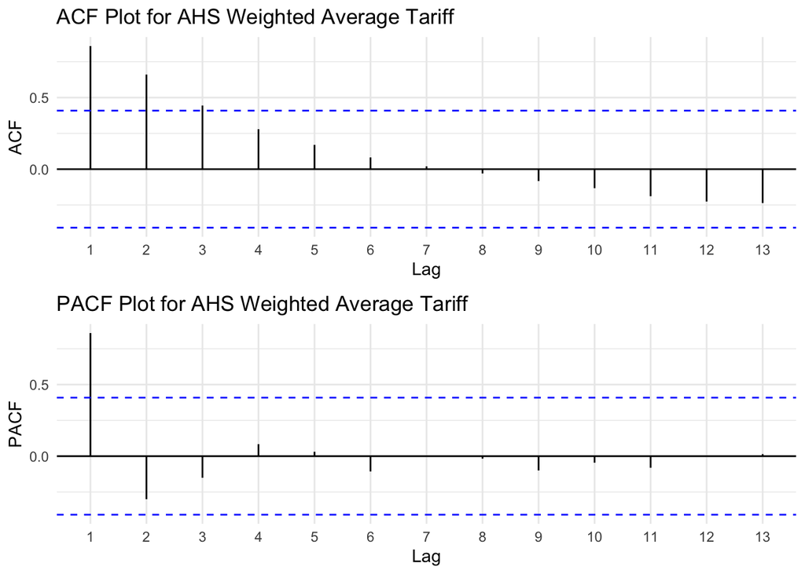

```r
acf7 <- ggAcf(ahs_ts) +
  ggtitle("ACF Plot for AHS Weighted Average Tariff") +
  theme_minimal()

pacf7 <- ggPacf(ahs_ts) +
  ggtitle("PACF Plot for AHS Weighted Average Tariff") +
  theme_minimal()

grid.arrange(acf7, pacf7, nrow = 2)
```

The ACF plot for the AHS Weighted Average Tariff shows a sharp decline after the first lag, with only the first few lags being significant. The PACF plot mirrors this pattern with a strong spike at lag 1 and quickly diminishing correlations thereafter. This suggests that the tariff series is weakly persistent but relatively more stationary compared with other variables, indicating limited serial dependence and low long-term inertia.

**S&P 500 Index**

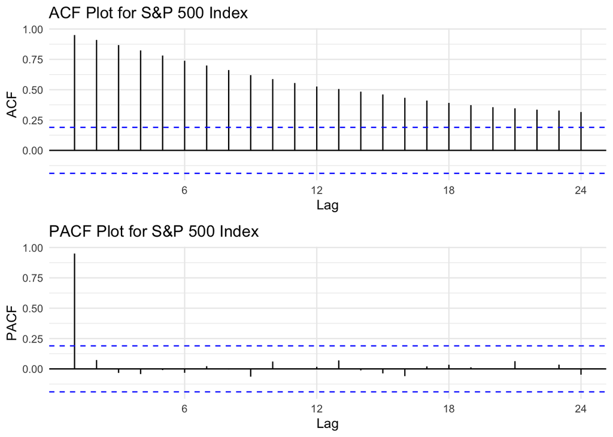

```r
acf8 <- ggAcf(sp500_ts) +
  ggtitle("ACF Plot for S&P 500 Index") +
  theme_minimal()

pacf8 <- ggPacf(sp500_ts) +
  ggtitle("PACF Plot for S&P 500 Index") +
  theme_minimal()

grid.arrange(acf8, pacf8, nrow = 2)
```

The ACF plot for the S&P 500 Index shows a slow and gradual decay in autocorrelation values across lags, indicating strong persistence and trend behavior in the series. The autocorrelation remains positive for many lags before declining gradually toward zero. The PACF plot exhibits a single dominant spike at lag 1 followed by values close to zero, suggesting that the series is non-stationary and likely contains a unit root. Such patterns are typical of financial market indices that follow long-term trends with persistent autocorrelation structures.

**U.S. Retail & Food Services Sales**

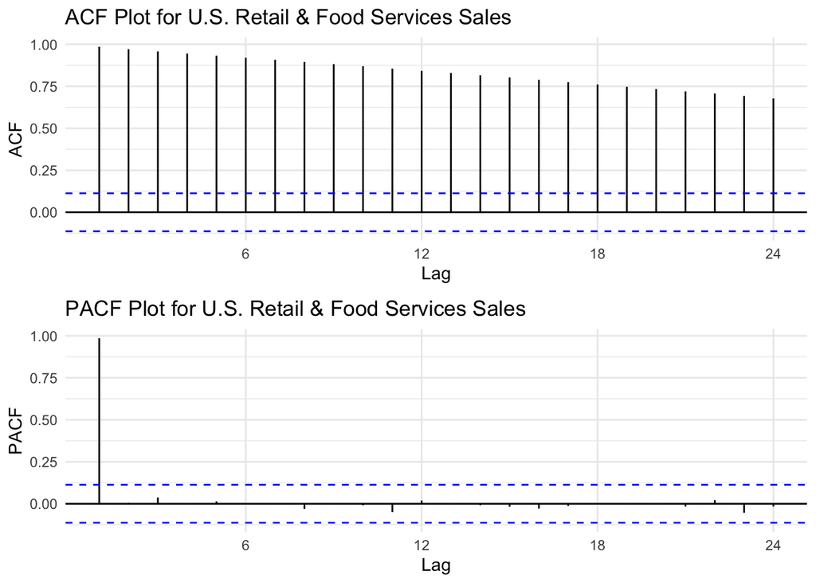

```r
acf9 <- ggAcf(rsafs_ts) +
  ggtitle("ACF Plot for U.S. Retail & Food Services Sales") +
  theme_minimal()

pacf9 <- ggPacf(rsafs_ts) +
  ggtitle("PACF Plot for U.S. Retail & Food Services Sales") +
  theme_minimal()

grid.arrange(acf9, pacf9, nrow = 2)
```

The ACF plot for U.S. Retail & Food Services Sales reveals a very slow decay of autocorrelation coefficients, remaining highly positive across many lags. This indicates strong persistence and a possible upward trend in the series over time. The PACF plot displays a single sharp spike at lag 1, after which values become insignificant. This pattern suggests that the series is non-stationary and likely requires differencing to remove trend and stabilize the variance before modeling.

# 5. Augmented Dickey-Fuller Test

**Loaded Imports**

```r
adf.test(la_li_ts)
```

```
    Augmented Dickey-Fuller Test

data:  la_li_ts
Dickey-Fuller = -4.9507, Lag order = 6, p-value = 0.01
alternative hypothesis: stationary
```

**Loaded Exports**

```r
adf.test(la_le_ts)
```

```
    Augmented Dickey-Fuller Test

data:  la_le_ts
Dickey-Fuller = -1.5969, Lag order = 6, p-value = 0.7462
alternative hypothesis: stationary
```

**Brent Crude Oil Price**

```r
adf.test(brent_ts)
```

```
    Augmented Dickey-Fuller Test

data:  brent_ts
Dickey-Fuller = -2.3108, Lag order = 6, p-value = 0.4453
alternative hypothesis: stationary
```

**U.S. Dollar Index**

```r
adf.test(usd_ts)
```

```
    Augmented Dickey-Fuller Test

data:  usd_ts
Dickey-Fuller = -2.5552, Lag order = 4, p-value = 0.3463
alternative hypothesis: stationary
```

# Global Supply Chain Pressure Index

```r
adf.test(gscpi_ts)
```

```
    Augmented Dickey-Fuller Test

data:  gscpi_ts
Dickey-Fuller = -2.9868, Lag order = 6, p-value = 0.1604
alternative hypothesis: stationary
```

**AHS Weighted Average Tariff**

```r
adf.test(ahs_ts)
```

```
    Augmented Dickey-Fuller Test

data:  ahs_ts
Dickey-Fuller = -4.0936, Lag order = 2, p-value = 0.01999
alternative hypothesis: stationary
```

**S&P 500 Index**

```r
adf.test(sp500_ts)
```

```
    Augmented Dickey-Fuller Test

data:  sp500_ts
Dickey-Fuller = -1.3998, Lag order = 4, p-value = 0.8256
alternative hypothesis: stationary
```

**U.S. Retail & Food Services Sales**

```r
adf.test(rsafs_ts)
```

```
    Augmented Dickey-Fuller Test

data:  rsafs_ts
Dickey-Fuller = -0.29112, Lag order = 6, p-value = 0.99
alternative hypothesis: stationary
```

The ADF test results indicate that only Total TEUs, Loaded Imports, and AHS Weighted Average Tariff have p-values below 0.05, allowing us to conclude that these three series are stationary. In contrast, the other six variables — Loaded Exports, Brent Crude Oil Price, U.S. Dollar Index, Global Supply Chain Pressure Index, S&P 500 Index, and U.S. Retail & Food Services Sales — have p-values well above 0.05, meaning we fail to reject the null hypothesis. This suggests that these series are non-stationary, consistent with the strong persistence and slow-decaying autocorrelations observed in their ACF and PACF plots.

Therefore, to achieve stationarity and enable reliable time-series modeling, differencing or detrending should be applied to the non-stationary variables before proceeding with further analysis.

# 6. Differencing

**Total TEUs**

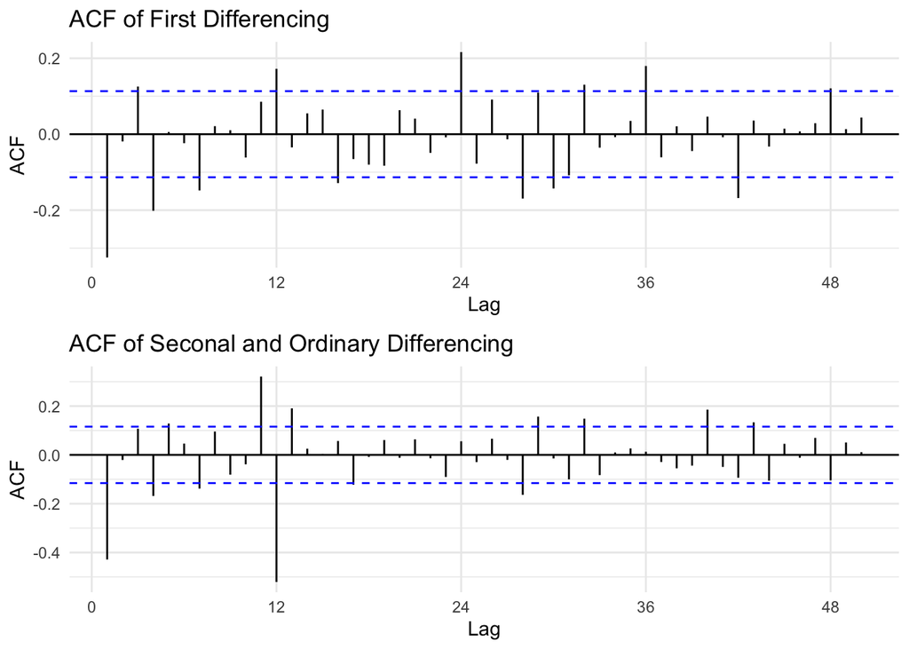

```r
diff1_teu <- ggAcf(diff(la_teu_ts), 50, main="ACF of First Differencing")+
           theme_minimal()

diff2_teu <- ggAcf(diff(diff(la_teu_ts, lag=12)), 50, main="ACF of Seconal and Ordinary Differencing")+
           theme_minimal()
grid.arrange(diff1_teu, diff2_teu, nrow=2)
```

**Loaded Imports**

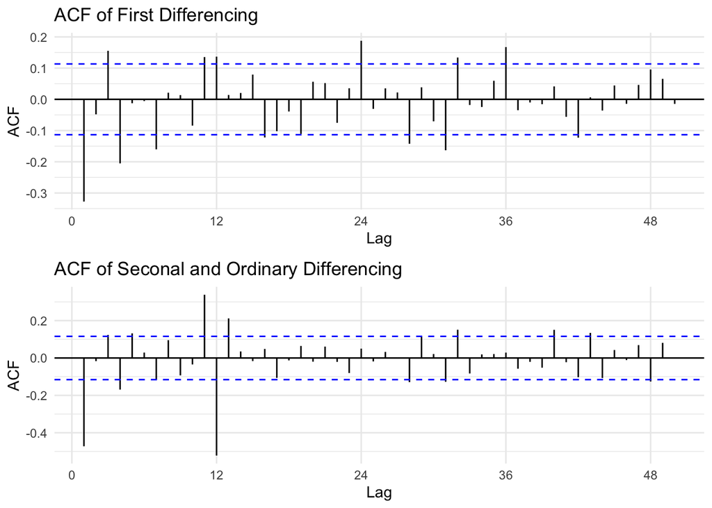

```r
# First differencing
diff1_li <- ggAcf(diff(la_li_ts, differences = 1), lag.max = 50) +
  ggtitle("ACF of First Differencing") +
  theme_minimal()

diff2_li <- ggAcf(diff(diff(la_li_ts, lag=12)), 50, main="ACF of Seconal and Ordinary Differencing")+
           theme_minimal()

grid.arrange(diff1_li, diff2_li, nrow=2)
```

**Loaded Exports**

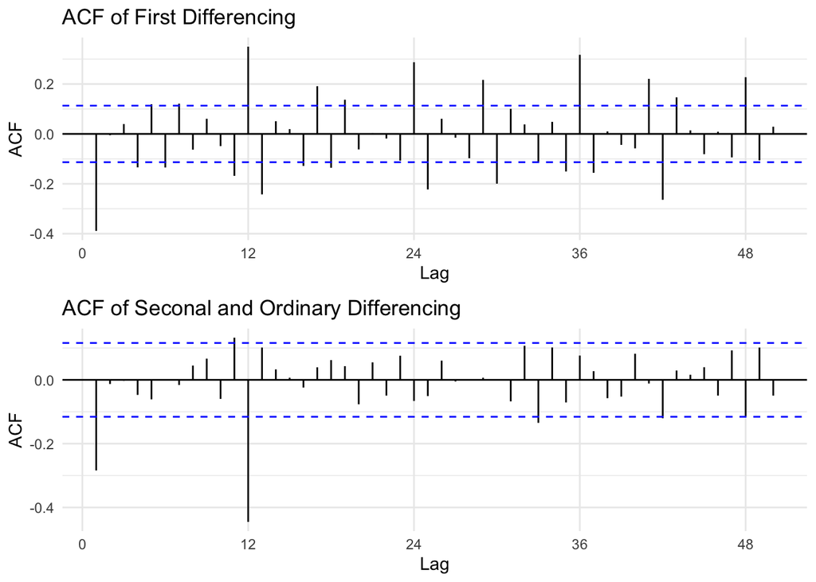

```r
# First differencing
diff1_le <- ggAcf(diff(la_le_ts, differences = 1), lag.max = 50) +
  ggtitle("ACF of First Differencing") +
  theme_minimal()


diff2_le <- ggAcf(diff(diff(la_le_ts, lag=12)), 50, main="ACF of Seconal and Ordinary Differencing")+
           theme_minimal()

grid.arrange(diff1_le, diff2_le, nrow=2)
```

**Brent Crude Oil Price**

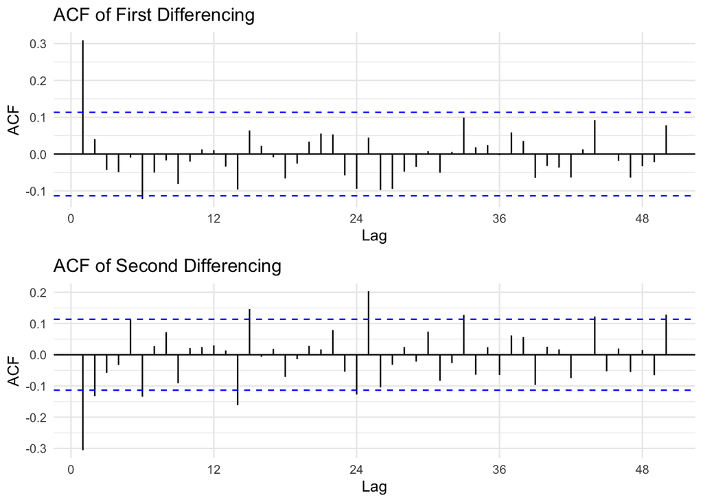

```r
# First differencing
diff1_brent <- ggAcf(diff(brent_ts, differences = 1), lag.max = 50) +
  ggtitle("ACF of First Differencing") +
  theme_minimal()

# Second differencing
diff2_brent <- ggAcf(diff(brent_ts, differences = 2), lag.max = 50) +
  ggtitle("ACF of Second Differencing") +
  theme_minimal()

# Combine the plots
grid.arrange(diff1_brent, diff2_brent, nrow = 2)
```

For the Brent Crude Oil Price series, the ACF plot after the first differencing shows that most autocorrelation values fall within the confidence bounds, with no clear seasonal or long-term correlation remaining. This indicates that the first differencing successfully removes the trend and makes the series approximately stationary. The second differencing does not provide significant additional improvement, confirming that the first differencing is sufficient for achieving stationarity and preparing the data for further time series modeling.

**U.S. Dollar Index**

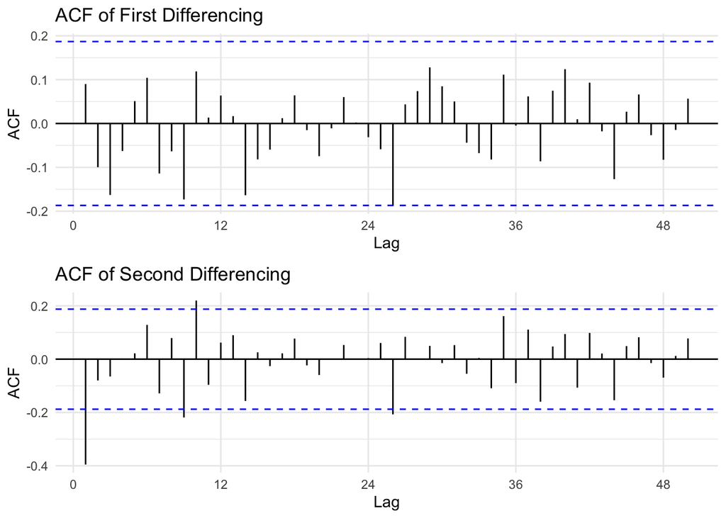

```r
# First differencing
diff1_usd <- ggAcf(diff(usd_ts, differences = 1), lag.max = 50) +
  ggtitle("ACF of First Differencing") +
  theme_minimal()

# Second differencing
diff2_usd <- ggAcf(diff(usd_ts, differences = 2), lag.max = 50) +
  ggtitle("ACF of Second Differencing") +
  theme_minimal()

# Combine the plots
grid.arrange(diff1_usd, diff2_usd, nrow = 2)
```

For the U.S. Dollar Index series, the ACF plot after the first differencing shows that most autocorrelation values lie within the confidence bounds, and no significant seasonal or long-term correlation is observed. This indicates that the first differencing has effectively removed the trend and achieved approximate stationarity. The second differencing does not yield any meaningful improvement, confirming that one order of differencing is sufficient for stabilizing the U.S. Dollar Index series for further time series modeling.

**Global Supply Chain Pressure Index**

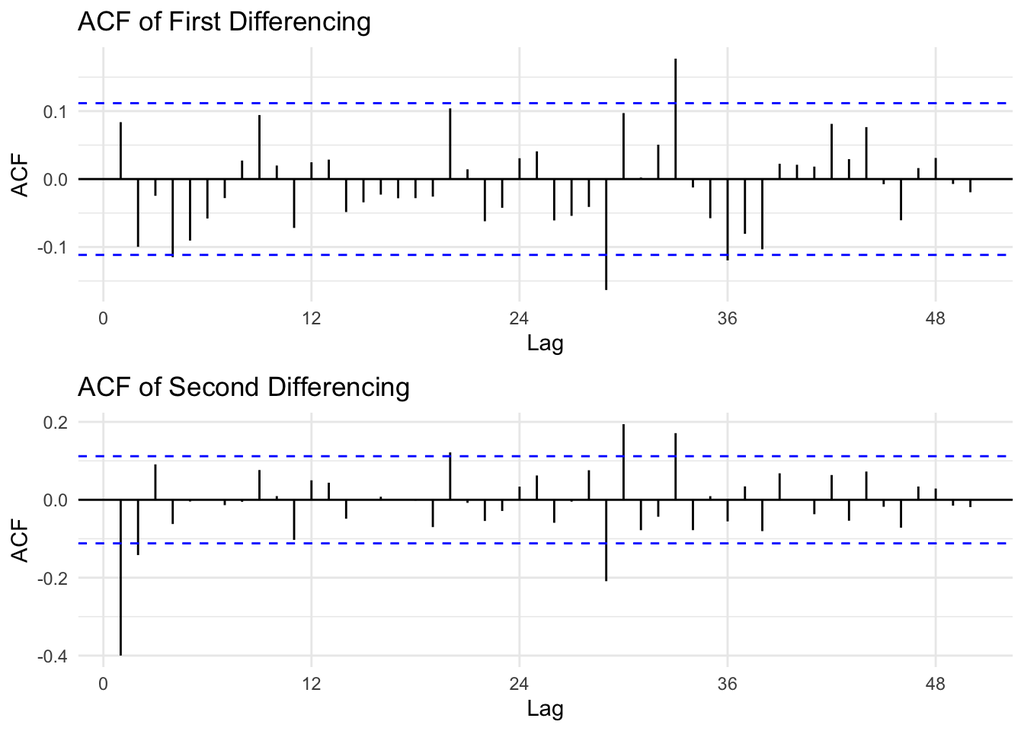

```r
 # First differencing
diff1_gscpi <- ggAcf(diff(gscpi_ts, differences = 1), lag.max = 50) +
  ggtitle("ACF of First Differencing") +
  theme_minimal()

# Second differencing
diff2_gscpi <- ggAcf(diff(gscpi_ts, differences = 2), lag.max = 50) +
  ggtitle("ACF of Second Differencing") +
  theme_minimal()

# Combine the plots
grid.arrange(diff1_gscpi, diff2_gscpi, nrow = 2)
```

For the Global Supply Chain Pressure Index series, the ACF plot after the first differencing shows that most autocorrelation values lie within the confidence bounds, and no significant seasonal or long-term correlation is observed. This indicates that the first differencing has effectively removed the trend and achieved approximate stationarity. The second differencing does not yield any meaningful improvement, confirming that one order of differencing is sufficient for stabilizing the Global Supply Chain Pressure Index series for further time series modeling.

**AHS Weighted Average Tariff**

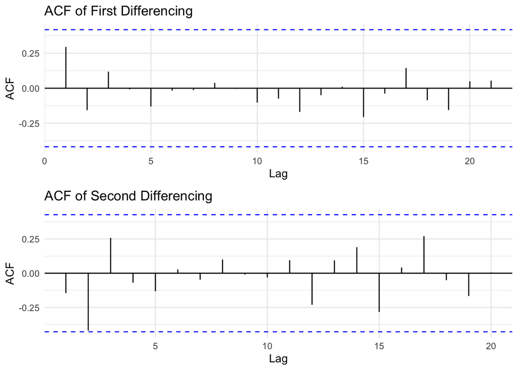

```r
# First differencing
diff1_ahs <- ggAcf(diff(ahs_ts, differences = 1), lag.max = 50) +
  ggtitle("ACF of First Differencing") +
  theme_minimal()

# Second differencing
diff2_ahs <- ggAcf(diff(ahs_ts, differences = 2), lag.max = 50) +
  ggtitle("ACF of Second Differencing") +
  theme_minimal()

grid.arrange(diff1_ahs, diff2_ahs, nrow = 2)
```

**S&P 500 Index**

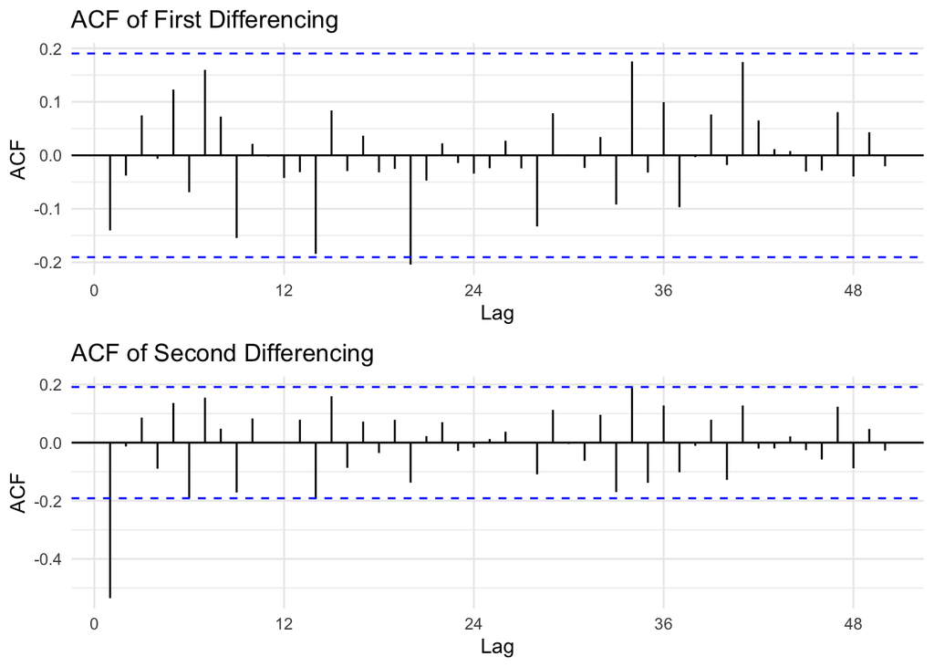

```r
# First differencing
diff1_sp500 <- ggAcf(diff(sp500_ts, differences = 1), lag.max = 50) +
  ggtitle("ACF of First Differencing") +
  theme_minimal()

# Second differencing
diff2_sp500 <- ggAcf(diff(sp500_ts, differences = 2), lag.max = 50) +
  ggtitle("ACF of Second Differencing") +
  theme_minimal()

# Combine the plots
grid.arrange(diff1_sp500, diff2_sp500, nrow = 2)
```

For the S&P 500 Index series, the ACF plot after the first differencing shows that most autocorrelation values fall within the confidence bounds, suggesting that the series appears approximately stationary. However, the ADF test result indicates that the series only becomes statistically stationary after the second differencing. Therefore, although the visual inspection of the ACF plot suggests near-stationarity after the first differencing, the second differencing is required to ensure full stationarity for subsequent time series modeling.

**U.S. Retail & Food Services Sales**

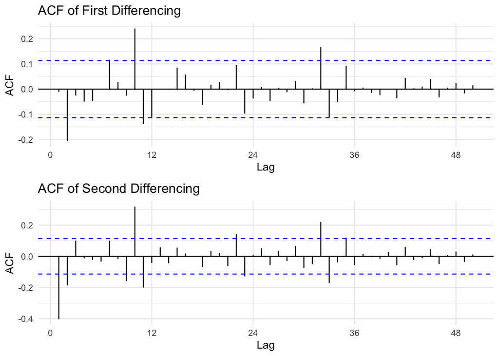

```r
# First differencing
diff1_rsafs <- ggAcf(diff(rsafs_ts, differences = 1), lag.max = 50) +
  ggtitle("ACF of First Differencing") +
  theme_minimal()

# Second differencing
diff2_rsafs <- ggAcf(diff(rsafs_ts, differences = 2), lag.max = 50) +
  ggtitle("ACF of Second Differencing") +
  theme_minimal()

# Combine the plots
grid.arrange(diff1_rsafs, diff2_rsafs, nrow = 2)
```

The ACF plots suggest that the U.S. Retail & Food Services Sales series achieves approximate stationarity after the first differencing. Most autocorrelation values fall within the confidence bounds, and no strong persistence or periodic structure remains. Applying a second differencing does not yield substantial improvement and may introduce unnecessary noise. Therefore, the first differencing is sufficient for achieving stationarity and suitable for subsequent time series modeling.

# 7. ADF Test after Differencing

**Total TEUs**

```r
adf.test(diff(diff(la_teu_ts, lag=12)))
```

```
    Augmented Dickey-Fuller Test

data:  diff(diff(la_teu_ts, lag = 12))
Dickey-Fuller = -7.1374, Lag order = 6, p-value = 0.01
alternative hypothesis: stationary
```

**Loaded Imports**

```r
adf.test(diff(diff(la_li_ts, lag=12)))
```

```
    Augmented Dickey-Fuller Test

data:  diff(diff(la_li_ts, lag = 12))
Dickey-Fuller = -7.2271, Lag order = 6, p-value = 0.01
alternative hypothesis: stationary
```

**Loaded Exports**

```r
adf.test(diff(diff(la_le_ts, lag=12)))
```

```
    Augmented Dickey-Fuller Test

data:  diff(diff(la_le_ts, lag = 12))
Dickey-Fuller = -8.1891, Lag order = 6, p-value = 0.01
alternative hypothesis: stationary
```

**Brent Crude Oil Price**

```r
adf.test(diff(brent_ts))
```

```
    Augmented Dickey-Fuller Test

data:  diff(brent_ts)
Dickey-Fuller = -6.8464, Lag order = 6, p-value = 0.01
alternative hypothesis: stationary
```

**U.S. Dollar Index**

```r
adf.test(diff(usd_ts))
```

```
    Augmented Dickey-Fuller Test

data:  diff(usd_ts)
Dickey-Fuller = -4.8344, Lag order = 4, p-value = 0.01
alternative hypothesis: stationary
```

**Global Supply Chain Pressure Index**

```r
adf.test(diff(gscpi_ts))
```

```
    Augmented Dickey-Fuller Test

data:  diff(gscpi_ts)
Dickey-Fuller = -8.1878, Lag order = 6, p-value = 0.01
alternative hypothesis: stationary
```

**AHS Weighted Average Tariff**

```r
adf.test(diff(ahs_ts, differences = 2))
```

```
    Augmented Dickey-Fuller Test

data:  diff(ahs_ts, differences = 2)
Dickey-Fuller = -4.5253, Lag order = 2, p-value = 0.01
alternative hypothesis: stationary
```

**S&P 500 Index**

```r
adf.test(diff(sp500_ts, differences = 2))
```

```
    Augmented Dickey-Fuller Test

data:  diff(sp500_ts, differences = 2)
Dickey-Fuller = -7.564, Lag order = 4, p-value = 0.01
alternative hypothesis: stationary
```

**U.S. Retail & Food Services Sales**

```r
adf.test(diff(rsafs_ts))
```

```
    Augmented Dickey-Fuller Test

data:  diff(rsafs_ts)
Dickey-Fuller = -7.3225, Lag order = 6, p-value = 0.01
alternative hypothesis: stationary
```

# 8. Moving Average

**Total TEUs**

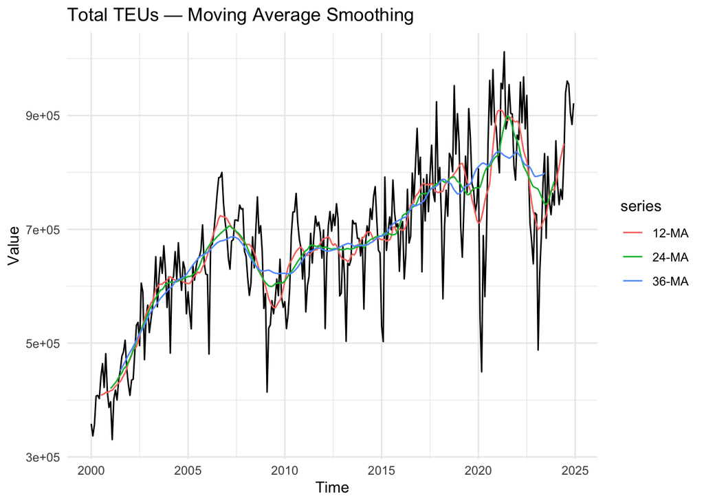

```r
library(forecast)
library(ggplot2)

autoplot(la_teu_ts) +
  autolayer(ma(la_teu_ts, 12), series = "12-MA") +
  autolayer(ma(la_teu_ts, 24), series = "24-MA") +
  autolayer(ma(la_teu_ts, 36), series = "36-MA") +
  labs(title = "Total TEUs — Moving Average Smoothing", y = "Value", x = "Time") +
  theme_minimal()
```

**Loaded Imports**

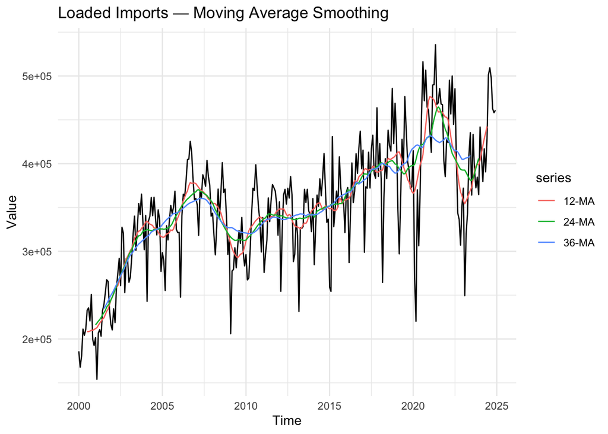

```r
autoplot(la_li_ts) +
  autolayer(ma(la_li_ts, 12), series = "12-MA") +
  autolayer(ma(la_li_ts, 24), series = "24-MA") +
  autolayer(ma(la_li_ts, 36), series = "36-MA") +
  labs(title = "Loaded Imports — Moving Average Smoothing", y = "Value", x = "Time") +
  theme_minimal()
```

**Loaded Exports**

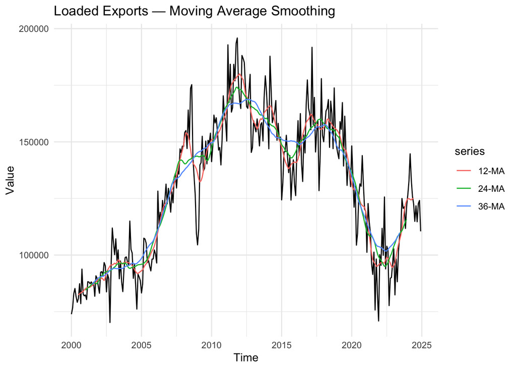

```r
autoplot(la_le_ts) +
  autolayer(ma(la_le_ts, 12), series = "12-MA") +
  autolayer(ma(la_le_ts, 24), series = "24-MA") +
  autolayer(ma(la_le_ts, 36), series = "36-MA") +
  labs(title = "Loaded Exports — Moving Average Smoothing", y = "Value", x = "Time") +
  theme_minimal()
```

**Brent Crude Oil Price**

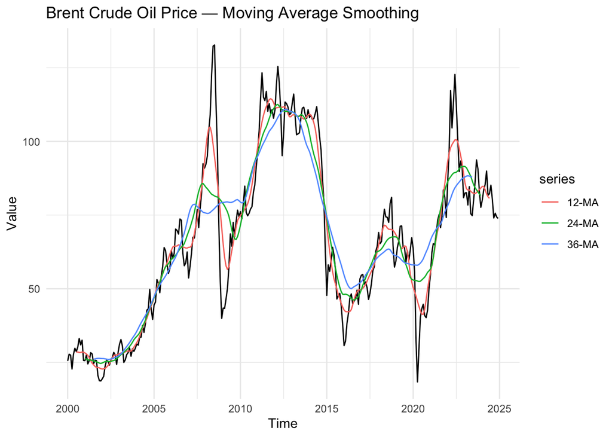

```r
autoplot(brent_ts) +
  autolayer(ma(brent_ts, 12), series = "12-MA") +
  autolayer(ma(brent_ts, 24), series = "24-MA") +
  autolayer(ma(brent_ts, 36), series = "36-MA") +
  labs(title = "Brent Crude Oil Price — Moving Average Smoothing", y = "Value", x = "Time") +
  theme_minimal()
```

**U.S. Dollar Index**

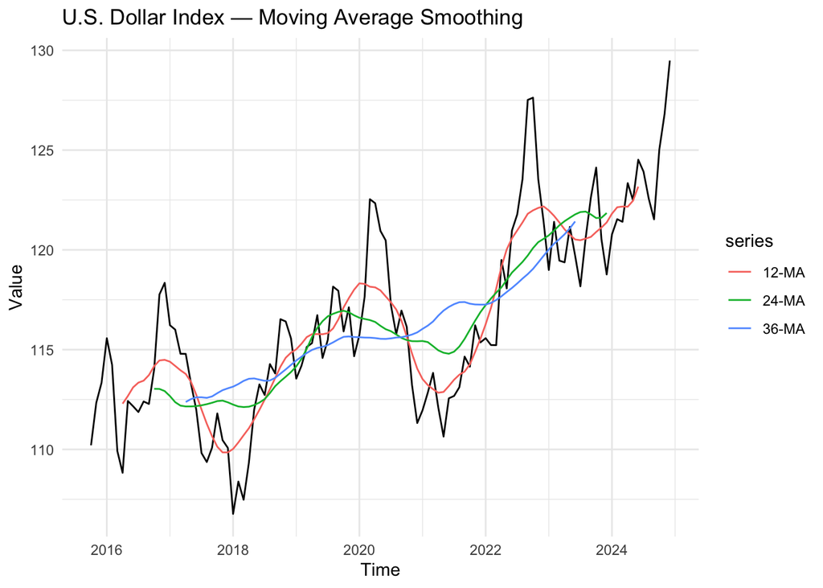

```r
autoplot(usd_ts) +
  autolayer(ma(usd_ts, 12), series = "12-MA") +
  autolayer(ma(usd_ts, 24), series = "24-MA") +
  autolayer(ma(usd_ts, 36), series = "36-MA") +
  labs(title = "U.S. Dollar Index — Moving Average Smoothing", y = "Value", x = "Time") +
  theme_minimal()
```

**Global Supply Chain Pressure Index**

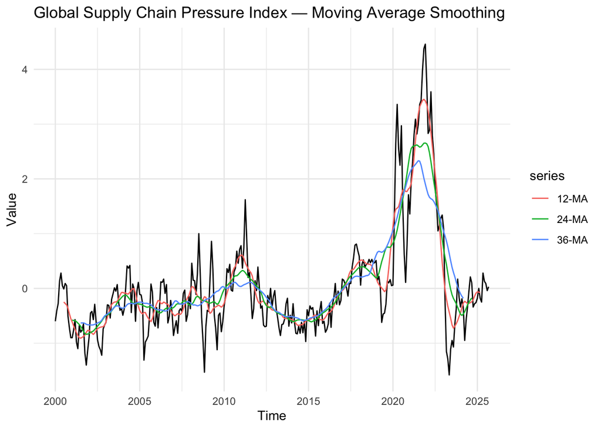

```r
autoplot(gscpi_ts) +
  autolayer(ma(gscpi_ts, 12), series = "12-MA") +
  autolayer(ma(gscpi_ts, 24), series = "24-MA") +
  autolayer(ma(gscpi_ts, 36), series = "36-MA") +
  labs(title = "Global Supply Chain Pressure Index — Moving Average Smoothing", y = "Value", x = "Time") +
  theme_minimal()
```

**AHS Weighted Average Tariff**

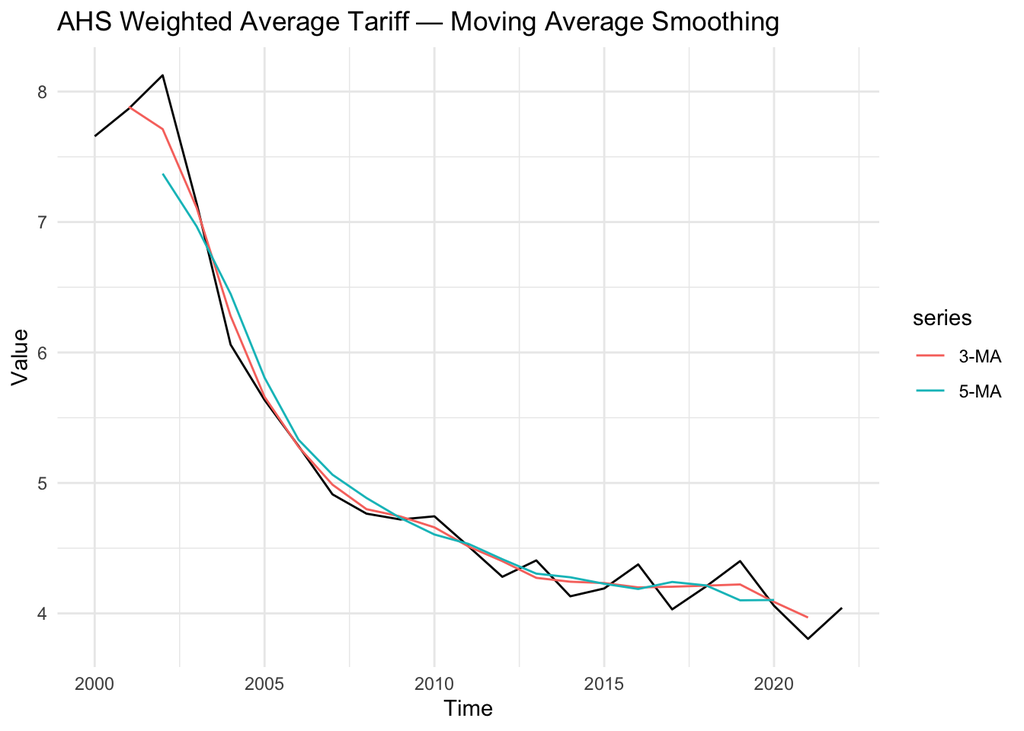

```r
autoplot(ahs_ts) +
  autolayer(ma(ahs_ts, 3), series = "3-MA") +
  autolayer(ma(ahs_ts, 5), series = "5-MA") +
  labs(title = "AHS Weighted Average Tariff — Moving Average Smoothing", y = "Value", x = "Time") +
  theme_minimal()
```

**S&P 500 Index**

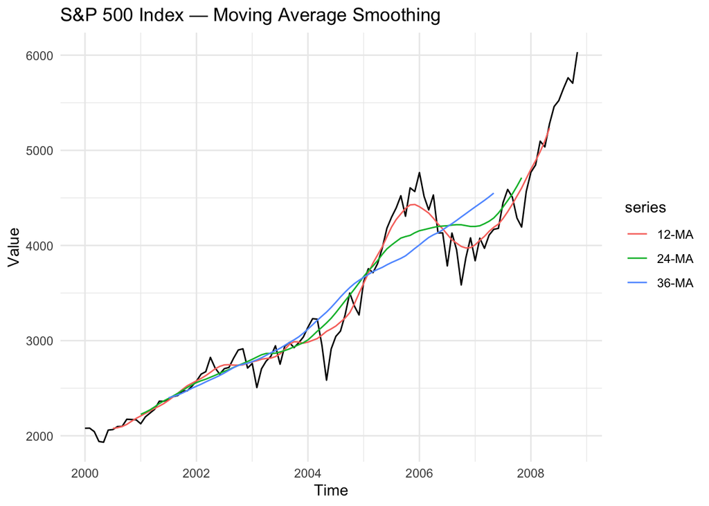

```r
autoplot(sp500_ts) +
  autolayer(ma(sp500_ts, 12), series = "12-MA") +
  autolayer(ma(sp500_ts, 24), series = "24-MA") +
  autolayer(ma(sp500_ts, 36), series = "36-MA") +
  labs(title = "S&P 500 Index — Moving Average Smoothing", y = "Value", x = "Time") +
  theme_minimal()
```

**U.S. Retail & Food Services Sales**

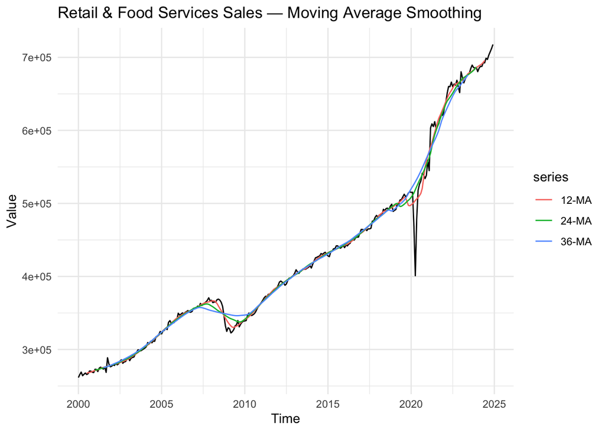

```r
autoplot(rsafs_ts) +
  autolayer(ma(rsafs_ts, 12), series = "12-MA") +
  autolayer(ma(rsafs_ts, 24), series = "24-MA") +
  autolayer(ma(rsafs_ts, 36), series = "36-MA") +
  labs(title = "Retail & Food Services Sales — Moving Average Smoothing", y = "Value", x = "Time") +
  theme_minimal()
```